# QIIME2R Analysis

Install qiime2R (if (!requireNamespace(“devtools”, quietly = TRUE)){install.packages(“devtools”)} devtools::install_github(“jbisanz/qiime2R”) # current version is 0.99.20)

Load libraries

Read in a table of sequence variants SVs

```r
SVs <- read_qza("~/Desktop/JF_metagenome/analysis_QIIME2-R230325/qiime2-out/table.qza")
```

When the artifact is imported, there are a number of pieces of information included. To see them we can use the names command:

```r
names(SVs)
```

To access the actual data stored within the object, access the data as below:

```r
SVs$data[1:5,1:5] #show first 5 samples and first 5 taxa
```

In the above file each row denotes a sequence variant where in the actual text is the hash of the complete sequence.

```r
seqtab<-SVs$data
```

Reading Metadata If you are using a qiime2 metadata file, you can use the supplied function read_q2metadata() as below. If using a standard tsv or csv file, you can use read.table(), readr::read_tsv(), or readr::csv().

```r
metadata<-read_q2metadata("~/Desktop/JF_metagenome/analysis_QIIME2-R230325/jf-metadata.tsv")
head(metadata) # show top lines of metadata
```

Reading Taxonomy Note, when taxonomy is imported, a single string is returned along with a confidence score. For many analysis we will want to break up this string and for that purpose the parse_taxonomy() function is provided:

```r
taxonomy<-read_qza("~/Desktop/JF_metagenome/analysis_QIIME2-R230325/qiime2-out/taxonomy.qza")
taxonomy<-parse_taxonomy(taxonomy$data)
head(taxonomy)
```

Creating a Phyloseq Object A wrapper function called qza_to_phyloseq() is provided which links multiple read_qza() calls together to create a phyloseq object for subsequent analysis as per the phyloseq tutorials.

```r
ps<-qza_to_phyloseq(
    features="~/Desktop/JF_metagenome/analysis_QIIME2-R230325/qiime2-out/table.qza",
    tree="~/Desktop/JF_metagenome/analysis_QIIME2-R230325/qiime2-out/rooted-tree.qza",
    taxonomy = "~/Desktop/JF_metagenome/analysis_QIIME2-R230325/qiime2-out/taxonomy.qza",
    metadata = "~/Desktop/JF_metagenome/analysis_QIIME2-R230325/jf-metadata.tsv"
    )
ps
```

retain kingdom-bacteria

```r
# subset phyloseq object to include only bacteria
ps_bac <- subset_taxa(ps, Kingdom=="d__Bacteria")
# verify that only bacteria remain
tax_table(ps_bac)
ps_bac
```

Rename otu table

```r
# rename the OUT-table
taxa_names(ps_bac) <- paste0("OTU", seq(ntaxa(ps_bac)))
taxa_names(ps_bac)
```

Visualization

For publication-ready figures we will use tidyverse package extensively. The pipe operator (%>%) will be used frequently here to passes the output of one line to the next.

## Diversity Statistics:

Diversity in the ecological sense is intuitively understood as the complexity of a community of organisms. There are many ways to quantify this complexity so that we can compare communities objectively. The two main categories of methods are known as alpha diversity and beta diversity (Whittaker 1960). Alpha diversity measures the diversity within a single sample and is generally based on the number and relative abundance of taxa at some rank (e.g. species or OTUs). Beta diversity also uses the number of relative abundance of taxa at some rank, but measures variation between samples. In other words, an alpha diversity statistic describes a single sample and a beta diversity statistic describes how two samples compare.

The vegan package is the main tool set used for calculating biological diversity statistics in R.

####Alpha Diversity Over Time

Data required: Metadata Shannon Diversity

```r
metadata<-read_q2metadata("~/Desktop/JF_metagenome/analysis_QIIME2-R230325/jf-metadata.tsv")
shannon<-read_qza("~/Desktop/JF_metagenome/analysis_QIIME2-R230325/qiime2-out/core-metrics-results/shannon_vector.qza")

shannon<-shannon$data %>% rownames_to_column("SampleID") # this moves the sample names to a new column that matches the metadata and allows them to be merged
```

Look at the data to confirm that everything is okay.

```r
gplots::venn(list(metadata=metadata$SampleID, shannon=shannon$SampleID))
```

```r
metadata <- left_join(metadata, shannon, by = "SampleID")
head(metadata)
```

we have now added a column for the Shannon diversity to our table which will make everything easy to plot. Given this data set is longitudinal we can plot it as such. Note: the code I am using here would handle replicate data and plot error bars; however, this case does not have replicates. Also, a quick note is that R does generally not like -s in column names. To use these names we can surround them with ticks.

```r
#metadata$day <- as.numeric(levels(metadata$day))[metadata$day] # the columns in the metadata were all categorical
metadata %>%
  ggplot(aes(x=`day`, y=shannon_entropy, color=`experiment`, group = experiment, shape = `day`)) +
  stat_summary(geom="errorbar", fun.data=mean_se, width=1) +
  stat_summary(geom="line", fun.data=mean_se) +
  stat_summary(geom="point", fun.data=mean_se) +
  xlab("Day") +
  ylab("Shannon Diversity") +
  theme_q2r() + # try other themes like theme_bw() or theme_classic()
  scale_x_continuous(breaks = seq(0, 10, by = 2))+
  scale_color_viridis_d(name="Treatment",  option = "D") + # use different color scale which is color blind friendly
  facet_grid(. ~ site, scales = "free_x", space = "free_x")
 ggsave("Shannon_by_temp_trend.pdf", height=4, width=6, device="pdf") # save a PDF 3 inches by 4 inches
```

Abundances for taxonomic groups (‘OTU table’) as a TaxaxSamples matrix:

```r
# Absolute abundances
otu.absolute <- abundances(ps_bac)

# Relative abundances
otu.relative <- abundances(ps_bac, "compositional")
```

Pick metadata as data.frame:

```r
meta <- meta(ps_bac)
```

Total read counts

```r
reads_sample <- readcount(ps_bac)
# check for first 5 samples
reads_sample[1:5]
```

Add read per sample to phyloseq object metadata.

```r
meta<-sample_data(ps_bac)$reads_sample <- reads_sample
```

Alpha diversity

Global indicators: A comprehensive list of global indicators of the ecosystem state can be obtained as follows. This includes various measures of richness, evenness, diversity, dominance, and rarity with default parameters. See the individual functions for more options regarding parameter tuning.

```r
tab <-microbiome::alpha(ps_bac, index = "all")
kable(head(tab))
```

Dominance The dominance index refers to the abundance of the most abundant species. Various dominance indices are available (see the function help for a list of options).

# Absolute abundances for the single most abundant taxa in each sample

```r
tab_domi <- dominance(ps_bac, index = "all")
kable(head(tab_domi))
```

Rarity and low abundance The rarity indices quantify the concentration of rare or low abundance taxa. Various rarity indices are available (see the function help for a list of options).

```r
tab_rare <- rarity(ps_bac, index = "all")
kable(head(tab_rare))
```

Gini index Gini index is a common measure for inequality in economical income. The inverse gini index (1/x) can also be used as a community diversity measure.

```r
tab_ineq <- inequality(ps_bac)
kable(head(tab_ineq))
```

Evenness Various evenness measures are also available.

```r
tab_even <- evenness(ps_bac,'all')
kable(head(tab_even))
```

Create a list of pairwise comparison

```r
comp_treatment <- levels(meta$treatment) # get the variables

# make a pairwise list that we want to compare.
treatment.pairs <- combn(seq_along(comp_treatment), 2, simplify = FALSE, FUN = function(i)comp_treatment[i])

print(treatment.pairs)
```

```r
p.shannon <- boxplot_alpha(ps_bac,
                           index = "shannon",
                           x_var = "treatment", fill.colors= c("#E69F00","#E69F00", "#009E73", "#009E73", "#56B4E9", "#56B4E9"))

p.shannon <- p.shannon + theme_classic() +
  labs(x="Site", y="Shannon diversity")

p.shannon + stat_compare_means(comparisons = treatment.pairs)
ggsave("Shannon_by_pvalue.pdf", height=4, width=5, device="pdf") # save a PDF 3 inches by 4 inches
```

```r
p.shannon <- boxplot_alpha(ps_bac,
                           index = "shannon",
                           x_var = "treatment")

p.shannon <- p.shannon + theme_classic() +
  labs(x="Treatment", y="Shannon diversity")

p.shannon
```

Add diversity table to the metadata

```r
meta$Shannon <- tab$diversity_shannon
meta$InverseSimpson <- tab$diversity_inverse_simpson
```

```r
v1 <- ggviolin(meta, x = "site", y = "Shannon",
 add = "boxplot", fill = "site", palette = c("#E69F00", "#009E73", "#56B4E9"))
print(v1)
```

```r
v2 <- v1 + stat_compare_means(comparisons = site.pairs)
print(v2)
```

The Bray-Curtis dissimilarity is based on occurrence data (abundance), while the Jaccard distance is based on presence/absence data (does not include abundance information). UniFrac distances take into account the occurrence table and the phylogeny diversity (sequence distance). Weighted or unweighted UniFrac distances depending if taking into account relative abundance or only presence/absence. Distances metrics are between 0 and 1: 0 means identical communities in both samples and 1 means different communities in both samples.

```r
# Perform PCoA
pcoa_result <- ordinate(ps_bac, method = "DCA", distance = "bray", formula = ~ day)

# Plot PCoA
plot_ordination(ps_bac, pcoa_result, type = "sites", color = "experiment", shape = "site")
ggsave("full_PCoA-DCA_Bray-sample.pdf", height = 4, width = 6, device = "pdf")# save a PDF 4 inches by 6 inches
```

```r
plot_ordination(ps_bac, pcoa_result, type = "split", color = "Phylum", title = "PCoA Plot", shape = "site")
ggsave("full_PCoA-DCA_Bray-split-phylum.pdf", height = 6, width = 12, device = "pdf")# save a PDF 4 inches by 6 inches
```

#### Alpha (within sample) diversity

Common alpha diversity statistics include:

Shannon: How difficult it is to predict the identity of a randomly chosen individual. Simpson: The probability that two randomly chosen individuals are the same species. Inverse Simpson: This is a bit confusing to think about. Assuming a theoretically community where all species were equally abundant, this would be the number of species needed to have the same Simpson index value for the community being analyzed.

Alpha-diversity per sample

##Heatmap

```r
library(pheatmap)
# Extract OTU table
otu_table <- as.data.frame(otu_table(ps_bac))
# Transpose the OTU table to have samples as rows and taxa as columns
otu_table <- t(otu_table)
# Set row names to sample names
rownames(otu_table) <- sample_names(ps_bac)
# Normalize data to relative abundance
otu_table <- otu_table/rowSums(otu_table)
# Select the top 50 taxa by mean relative abundance
otu_table <- otu_table[order(rowMeans(otu_table), decreasing = TRUE),][1:50,]
# Plot heatmap
pheatmap(otu_table,
         cluster_rows = TRUE,
         cluster_cols = FALSE,
         border_color = NA,
         main = "Relative Abundance Heatmap",
         cellwidth = 15,
         cellheight = 10,
         fontsize = 8,
         color = colorRampPalette(c("white", "blue"))(50))
```

```r
library(pheatmap)
library(phyloseq)

# Assume your phyloseq object is called "ps"
# Extract the OTU table
otu_tab <- otu_table(ps_bac)

# Generate a heatmap
pheatmap(otu_tab, scale = "row")
ggsave("heatmap-full", height = 4, width = 10, device = "pdf")# save a PDF 4 inches by 10 inches
```

```r
ps_top100 <- prune_taxa(names(sort(taxa_sums(ps_bac), decreasing = TRUE)[1:100]), ps_bac)

plot_heatmap(ps_top100, method = "MDS", distance = "bray",
  sample.label = 'day', taxa.label = "Phylum", low = "grey",
  high = "navy", na.value = "white",
  max.label = 250, title = NULL, sample.order = NULL,
  taxa.order = NULL, first.sample = NULL, first.taxa = NULL)


library(ggplot2)
library(reshape2)
library(phyloseq)

# Assume your phyloseq object is called "ps"
# Extract the OTU table
otu_tab <- otu_table(ps_bac_na)

# Scale the data
otu_tab_scaled <- scale(t(otu_tab))

# Convert to long format
otu_tab_melted <- melt(as.data.frame(otu_tab_scaled))

# Plot a faceted heatmap using ggplot2
ggplot(otu_tab_melted, aes(x = variable, y = rownames(otu_tab_scaled), fill = value)) +
  geom_tile() +
  scale_fill_gradient(low = "white", high = "red") +
  facet_grid(. ~ SampleType) +
  theme(axis.text.x = element_text(angle = 90, hjust = 1))
```

## Absolute and relative abundance at Phylum level

```r
summary(ps_bac@tax_table@.Data== "NA")
```

```r
ps_bac_na <- subset_taxa(ps_bac, Genus !="NA")
```

```r
summary(ps_bac_na@tax_table@.Data== "NA")
```

Transform to percentages

```r
percentages <- transform_sample_counts(ps_bac_na, function(x) x*100 / sum(x))
head(percentages@otu_table@.Data)
```

We will start our exploration at the Phylum level. In order to group all the OTUs that have the same taxonomy at a certain taxonomic rank, we will use the function tax_glom().

```r
percentages_glom <- tax_glom(percentages, taxrank = 'Phylum')
View(percentages_glom@tax_table@.Data)
```

Another phyloseq function is psmelt(), which melts phyloseq objects into a data.frame to manipulate them with packages like ggplot2 and vegan.

```r
percentages_df <- psmelt(percentages_glom)
str(percentages_df)
```

```r
absolute_glom <- tax_glom(physeq = ps_bac_na, taxrank = "Phylum")
```

```r
absolute_df <- psmelt(absolute_glom)
str(absolute_df)
```

With these objects and what we have learned regarding R data structures and ggplot2, we can proceed to compare them with a plot. First, let’s take some steps that will allow us to personalize our plot making it accessible for color-blindness. We will create a color palette. With colorRampPalette we will choose 8 colors from the Dark2 palette and make a “ramp” with it, that is, convert those 8 colors to the number of colors needed to have one for each phylum in our data frame. For this we need to have our Phylum column in the factor structure.

```r
library(RColorBrewer)
absolute_df$Phylum <- as.factor(absolute_df$Phylum)
phylum_colors_abs<- colorRampPalette(brewer.pal(8,"Dark2")) (length(levels(absolute_df$Phylum)))
```

Now, let´s create the figure for the data with absolute abundances (i.e absolute_plot object)

```r
absolute_plot <- ggplot(data= absolute_df, aes(x=Sample, y=Abundance, fill=Phylum))+
    geom_bar(aes(), stat="identity", position="stack")+
    scale_fill_manual(values = phylum_colors_abs)+theme_classic()+ theme(axis.text.x = element_text(angle = 90, hjust = 1))
absolute_plot
```

```r
relative_plot <- ggplot(data= percentages_df, aes(x=Sample, y=Abundance, fill=Phylum))+
    geom_bar(aes(), stat="identity", position="stack")+
    scale_fill_manual(values = phylum_colors_abs)+theme_classic()+ theme(axis.text.x = element_text(angle = 90, hjust = 1)) + facet_grid(. ~ treatment, scales = "free_x", space = "free_x")
relative_plot
ggsave("Phyla-barplot.pdf", height = 4, width = 16, device = "pdf")# save a PDF 4 inches by 16 inches
```

## Extract specific phylum (Proteobacteria) for genus level inspection

```r
proteo <- subset_taxa(ps_bac_na, Phylum == "Proteobacteria")
unique(proteo@tax_table@.Data[,2])
```

```r
proteo_percentages <- transform_sample_counts(proteo, function(x) x*100 / sum(x))
```

```r
proteo_glom <- tax_glom(proteo_percentages, taxrank = "Genus")
```

```r
proteo_df <- psmelt(proteo_glom)
proteo_df$Genus[proteo_df$Abundance < 10] <- "Genera < 10.0 abund"
proteo_df$Genus <- as.factor(proteo_df$Genus)
genus_colors_proteo<- colorRampPalette(brewer.pal(8,"Dark2")) (length(levels(proteo_df$Genus)))
plot_proteo <- ggplot(data=proteo_df, aes(x=Sample, y=Abundance, fill=Genus))+
    geom_bar(aes(), stat="identity", position="stack")+
 scale_fill_manual(values = phylum_colors_abs)+theme_classic()+ theme(axis.text.x = element_text(angle = 90, hjust = 1)) + facet_grid(. ~ treatment, scales = "free_x", space = "free_x")
plot_proteo
ggsave("Proteo-genus barplot.pdf", height = 4, width = 16, device = "pdf")# save a PDF 4 inches by 16 inches
```

# Heatmap

```r
theme_set(theme_bw())
```

Plot heatmap from the filtered phyloseq object (ps_bac_na).

```r
hmap <- prune_taxa(names(sort(taxa_sums(ps_bac_na),TRUE)[1:50]), ps_bac_na)

plot_heatmap(hmap, sample.label="experiment", low="#66CCFF", high="#000033", na.value="white")
```

```r
# Assume your phyloseq object is called "ps"
# Extract the OTU table
otu_tab <- otu_table(hmap)
# Generate a heatmap
pheatmap(otu_tab, scale = "row", low="#66CCFF", high="#000033", na.value="white")
pheatmap(ps_bac_na,"MDS", "bray", "day", "Genus", low="#66CCFF", high="#000033", na.value="white")
```

```r
library(phyloseq)
library(ggplot2)

# Assume your phyloseq object is called "ps_bac"
# Extract the OTU table
otu_tab <- otu_table(ps_bac)

# Scale the OTU table
otu_tab_scaled <- t(scale(t(otu_tab)))

# Melt the scaled OTU table into a long format
otu_tab_melted <- melt(as.data.frame(otu_tab_scaled))

# Add a column for the site variable
otu_tab_melted$site <- sample_data(ps_bac)$site

# Plot a faceted heatmap
ggplot(otu_tab_melted, aes(x = variable, y = site, fill = value)) +
  geom_tile() +
  facet_grid(rows = vars(site)) +
  scale_fill_gradient(low = "grey", high = "orange", na.value = "black") +
  theme_bw() +
  theme(axis.text.x = element_text(angle = 90, vjust = 0.5, hjust=1))
```

## Phylum Bar plot:

## Class Bar plot:

## Order Bar plot:

## Family Bar plot:

## Genus Bar plot:

##Species Bar plot:

## Indepth analyses:

```r
library(tidyverse)
library(patchwork)
library(agricolae)
library(rcompanion)
```

```r
OTU <- otu_table(as.matrix(st.nochim), taxa_are_rows = FALSE)
SAM <- sample_data(df, errorIfNULL = TRUE)
TAX <-  tax_table(as.matrix(tax.species))
data_phylo <- phyloseq(OTU, TAX, SAM)
```

```r
data_phylo_filt <- filter_taxa(ps, function(x) sum(x > 2) > (0.11 * length(x)), TRUE)
set.seed(1782) # set seed for analysis reproducibility
OTU_filt_rar = rarefy_even_depth(otu_table(data_phylo_filt), rngseed = TRUE, replace = FALSE) # rarefy the raw data using Phyloseq package
data_otu_filt_rar = data.frame(otu_table(OTU_filt_rar)) # create a separated file
data_phylo_filt_rar <- phyloseq(OTU_filt_rar, taxonomy, df) # create a phyloseq object
```

## Distance calculation

```r
# calculate Bray-Curtis distance using the vegan package
dist_bc <- as.matrix(vegdist(data_otu_filt_rar, method = "bray"))

# a peek at the first five rows / columns
dist_bc[1:5, 1:5]
```

Visualisation using PCOA ordination plot In order to represent in a two dimensional plot from the huge inter-sample distances matrix (pairwise distances), we are doing a principal coordinate analysis (PCoA). Principal Component Analysis (PCA) is a special case of PCoA for which Euclidean distances are calculated between samples. However, PCoA works with any dissimilarity measure (such as Bray-Curtis, Jaccard or weight/unweight Unifrac distances) and so specific association coefficients that better deal with the problem of the presence of many double zeros in data sets can be surmounted. However, PCoA does not provide a direct link between the components and the original variables and so the interpretation of variable contribution may be more difficult. This is because PCoA components, instead of being linear combinations of the original variables as in PCA, are complex functions of the original variables depending on the selected dissimilarity measure.

Combined variables;

##Statistical test To test whether the groups are different with respect to centroid and dispersion, a PERMANOVA statistical test will be performed. For this a multivariate extension of ANOVA will be used, as there are many OTU that will be used in the test. The extension is based on distances between samples. The test compares distances of samples within the same group to distances of samples from different groups. If the distance between samples from the different groups is much larger than samples from the same group, we conclude that the groups are not equal.

In order to test the significance of the result, a permutation test is used. Thus all samples are randomly mixed over the groups and the test is repeated many times. If the ratio (between group distance / within group distance) is much larger for the original data than for the permutations, we conclude there is a statistical significant difference.

The test can be applied in combination with any distance measure. Here we use the Bray-Curtis distance as was also used for the PCoA above.

First, we will test if there is any significant effect of the sampling site.

```r
# Permanova test using the vegan package
adonis2(data_otu_filt_rar~site * day,  permutations=999, method="bray", data=df)
```

The Total Sum of Squares is obtained from summing up all squared distances and dividing this by the number of samples - 1. The Residuals sum of squares (or within group sum of squares) is obtained by adding all squared distances of samples in the same group and divide this by the number of samples per group. The site sum of squares (or between group sum of squares) = SSTotal - SSResiduals. The F.model value then is obtained by the ratio of the Mean Squares (which are the Sum of squares divided by their degrees of freedom). The fraction of permuted results that provide a higher F value than the original data Pr(>F) represents the p-value which is significant when < 0.05.

## Differential abundance test

```r
dseq <- phyloseq_to_deseq2(ps_bac_na, ~ site)
dseq <- DESeq(dseq, test="Wald", fitType="local")
```

Note: The default multiple-inference correction is Benjamini-Hochberg, and occurs within the DESeq function.

```r
res <- results(larvaedds, cooksCutoff = FALSE)
alpha = 0.05
sigtab = res[which(res$padj < alpha), ]
sigtab = cbind(as(sigtab, "data.frame"), as(tax_table(ps)[rownames(sigtab), ], "matrix"))
head(sigtab)
```

```r
dim(sigtab)
```

Let’s look at the OTUs that were significantly different between the two status. The following makes a nice ggplot2 summary of the results.

```r
theme_set(theme_bw())
scale_fill_discrete <- function(palname = "Set1", ...) {
    scale_fill_brewer(palette = palname, ...)
}
# Phylum order
x = tapply(sigtab$log2FoldChange, sigtab$Phylum, function(x) max(x))
x = sort(x, TRUE)
sigtab$Phylum = factor(as.character(sigtab$Phylum), levels=names(x))
# Genus order
x = tapply(sigtab$log2FoldChange, sigtab$Genus, function(x) max(x))
x = sort(x, TRUE)
sigtab$Genus = factor(as.character(sigtab$Genus), levels=names(x))
ggplot(sigtab, aes(x=Genus, y=log2FoldChange, color=Phylum)) + geom_point(size=6) +
  theme(axis.text.x = element_text(angle = -90, hjust = 0, vjust=0.5))
```

##Phylogentic relationships

## Construct phylogenetic tree

Phylogenetic relatedness is commonly used to inform downstream analyses, especially the calculation of phylogeny-aware distances between microbial communities. The DADA2 sequence inference method is reference-free, so we must construct the phylogenetic tree relating the inferred sequence variants de novo. We begin by performing a multiple-alignment using the DECIPHER R package (Wright 2015). library(DECIPHER)

```r
seqs <- getSequences(st.nochim)
names(seqs) <- seqs # This propagates to the tip labels of the tree
alignment <- AlignSeqs(DNAStringSet(seqs), anchor=NA,verbose=FALSE)
```

The phangorn R package is then used to construct a phylogenetic tree. Here we first construct a neighbor-joining tree, and then fit a GTR+G+I (Generalized time-reversible with Gamma rate variation) maximum likelihood tree using the neighbor-joining tree as a starting point. library(phangorn)

```r
phangAlign <- phyDat(as(alignment, "matrix"), type="DNA")
dm <- dist.ml(phangAlign)
treeNJ <- NJ(dm) # Note, tip order != sequence order
fit = pml(treeNJ, data=phangAlign)
fitGTR <- update(fit, k=4, inv=0.2)
fitGTR <- optim.pml(fitGTR, model="GTR", optInv=TRUE, optGamma=TRUE,
        rearrangement = "stochastic", control = pml.control(trace = 0))
detach("package:phangorn", unload=TRUE)
```

###Create phyloseq object 2

```r
ps2 <- phyloseq(otu_table(st.nochim, taxa_are_rows=FALSE),
               sample_data(df),
               tax_table(tax.species),
                phy_tree(fitGTR$tree))
ps2
```

##Filtering

phyloseq provides useful tools for filtering, subsetting, and agglomerating taxa – a task that is often appropriate or even necessary for effective analysis of microbiome count data. In this subsection, we graphically explore the prevalence of taxa in the dataset, and demonstrate how this can be used as a filtering criteria. One of the reasons to filter in this way is to avoid spending much time analyzing taxa that were seen only rarely among samples. This also turns out to be a useful filter of noise (taxa that are actually just artifacts of the data collection process), a step that should probably be considered essential for datasets constructed via heuristic OTU-clustering methods, which are notoriously prone to generating spurious taxa.

##Taxonomic Filtering In many biological settings, the set of all organisms from all samples are well-represented in the available taxonomic reference database. When (and only when) this is the case, it is reasonable or even advisable to filter taxonomic features for which a high-rank taxonomy could not be assigned. Such ambiguous features in this setting are almost always sequence artifacts that don’t exist in nature. It should be obvious that such a filter is not appropriate for samples from poorly characterized or novel specimens, at least until the possibility of taxonomic novelty can be satisfactorily rejected. Phylum is a useful taxonomic rank to consider using for this purpose, but others may work effectively for your data.

To begin, create a table of read counts for each Phylum present in the dataset. Show available ranks in the dataset

```r
rank_names(ps_bac_na)
```

Create table, number of features for each phyla

```r
table(tax_table(ps_bac_na)[, "Phylum"], exclude = NULL)
```

The following ensures that features with ambiguous phylum annotation are also removed. Note the flexibility in defining strings that should be considered ambiguous annotation.

```r
ps2 <- subset_taxa(ps_bac_na, !is.na(Phylum) & !Phylum %in% c("", "uncharacterized"))
```

A useful next step is to explore feature prevalence in the dataset, which we will define here as the number of samples in which a taxon appears at least once.

```r
# Compute prevalence of each feature, store as data.frame
prevdf <- apply(X = otu_table(ps2),
               MARGIN = ifelse(taxa_are_rows(ps2), yes = 1, no = 2),
               FUN = function(x){sum(x > 0)})
# Add taxonomy and total read counts to this data.frame
prevdf <- data.frame(Prevalence = prevdf,
                    TotalAbundance = taxa_sums(ps2),
                    tax_table(ps2))
```

Are there phyla that are comprised of mostly low-prevalence features? Compute the total and average prevalence of the features in each phylum.

```r
plyr::ddply(prevdf, "Phylum", function(df2){cbind(mean(df2$Prevalence),sum(df2$Prevalence))})
```

```r
# Define phyla to filter
filterPhyla <- c("SAR324_clade(Marine_group_B)", "WS2", "WPS-2", "Sva0485", "RCP2-54", "PAUC34f", "NB1-j", "MBNT15", "AncK6" )
# Filter entries with unidentified Phylum.
ps3 <- subset_taxa(ps2, !Phylum %in% filterPhyla)
ps3
```

Ambiguous phyla were removed from the list

#### Bar plot for filtered phyla

## Absolute and relative abundance at Phylum level

```r
summary(ps3@tax_table@.Data== "NA")
```

```r
ps3_na <- subset_taxa(ps3, Species !="NA")
```

```r
summary(ps3_na@tax_table@.Data== "NA")
```

Transform to percentages

```r
percentages_ps3 <- transform_sample_counts(ps3_na, function(x) x*100 / sum(x))
head(percentages@otu_table@.Data)
```

We will start our exploration at the Phylum level. In order to group all the OTUs that have the same taxonomy at a certain taxonomic rank, we will use the function tax_glom().

```r
percentages_glomps3 <- tax_glom(percentages_ps3, taxrank = 'Phylum')
View(percentages_glomps3@tax_table@.Data)
```

Another phyloseq function is psmelt(), which melts phyloseq objects into a data.frame to manipulate them with packages like ggplot2 and vegan.

```r
percentages_dfps3 <- psmelt(percentages_glomps3)
str(percentages_dfps3)
```

```r
absolute_glomps3 <- tax_glom(physeq = ps3_na, taxrank = "Phylum")
```

```r
absolute_dfps3 <- psmelt(absolute_glomps3)
str(absolute_dfps3)
```

```r
library(RColorBrewer)
absolute_dfps3$Phylum <- as.factor(absolute_dfps3$Phylum)
phylum_colors_abs<- colorRampPalette(brewer.pal(8,"Set2")) (length(levels(absolute_dfps3$Phylum)))
```

Now, let´s create the figure for the data with absolute abundances (i.e absolute_plot object)

```r
absolute_plotps3 <- ggplot(data= absolute_dfps3, aes(x=Sample, y=Abundance, fill=Phylum))+
    geom_bar(aes(), stat="identity", position="stack")+
    scale_fill_manual(values = phylum_colors_abs)+theme_classic()+ theme(axis.text.x = element_text(angle = 90, hjust = 1))
absolute_plotps3
```

```r
relative_plotps3 <- ggplot(data= percentages_dfps3, aes(x=Sample, y=Abundance, fill=Phylum))+
    geom_bar(aes(), stat="identity", position="stack")+
    scale_fill_manual(values = phylum_colors_abs)+theme_classic()+ theme(axis.text.x = element_text(angle = 90, hjust = 1)) + facet_grid(. ~ treatment, scales = "free_x", space = "free_x")
relative_plotps3
ggsave("Phyla-barplot-filtered.pdf", height = 6, width = 16, device = "pdf")# save a PDF 4 inches by 16 inches
```

## Extract specific phylum (Proteobacteria) for genus level inspection

```r
# Define genus to filter
filterGenus <- c("HglApr721", "uncultured", "OM60(NOR5)_clade", "Mitochondria" )
# Filter entries with unidentified Phylum.
ps4 <- subset_taxa(ps3, !Genus %in% filterGenus)
ps4
```

```
phyloseq-class experiment-level object
otu_table()   OTU Table:         [ 4730 taxa and 96 samples ]
sample_data() Sample Data:       [ 96 samples by 8 sample variables ]
tax_table()   Taxonomy Table:    [ 4730 taxa by 7 taxonomic ranks ]
phy_tree()    Phylogenetic Tree: [ 4730 tips and 4716 internal nodes ]
```

```r
# Define genus to filter
filterGenus <- c("37-13", "uncultured", "NS3a_marine_group", "NS9_marine_group", "NS10_marine_group", "NS11-12_marine_group" )
# Filter entries with unidentified Phylum.
ps5 <- subset_taxa(ps3, !Genus %in% filterGenus)
ps5
```

```
phyloseq-class experiment-level object
otu_table()   OTU Table:         [ 4741 taxa and 96 samples ]
sample_data() Sample Data:       [ 96 samples by 8 sample variables ]
tax_table()   Taxonomy Table:    [ 4741 taxa by 7 taxonomic ranks ]
phy_tree()    Phylogenetic Tree: [ 4741 tips and 4727 internal nodes ]
```

```r
proteops3 <- subset_taxa(ps4, Phylum == "Proteobacteria")
unique(proteops3@tax_table@.Data[,2])
```

```
[1] "Proteobacteria"
```

```r
bacteroips3 <- subset_taxa(ps5, Phylum == "Bacteroidota")
unique(bacteroips3@tax_table@.Data[,2])
```

```
[1] "Bacteroidota"
```

```r
proteo_percentagesps3 <- transform_sample_counts(proteops3, function(x) x*100 / sum(x))
```

```r
bactroi_percentagesps3 <- transform_sample_counts(bacteroips3, function(x) x*100 / sum(x))
```

```r
proteo_glomps3 <- tax_glom(proteo_percentagesps3, taxrank = "Genus")
```

```r
bacteroi_glomps3 <- tax_glom(bactroi_percentagesps3, taxrank = "Genus")
```

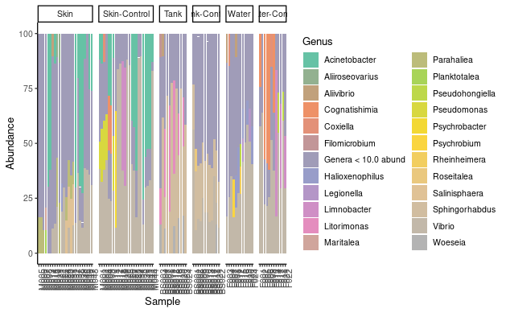

```r
proteo_dfps3 <- psmelt(proteo_glomps3)
proteo_dfps3$Genus[proteo_dfps3$Abundance < 10] <- "Genera < 10.0 abund"
proteo_dfps3$Genus <- as.factor(proteo_dfps3$Genus)

# Define colors for all genera
genus_colors_proteo <- colorRampPalette(brewer.pal(8, "Set2"))(length(levels(proteo_dfps3$Genus)))

# Set color for specific genus (GenusA)
#genus_colors_proteo[proteo_dfps3$Genus == "GenusA"] <- "red"

plot_proteops3 <- ggplot(data = proteo_dfps3, aes(x = Sample, y = Abundance, fill = Genus)) +
  geom_bar(aes(), stat = "identity", position = "stack") +
  scale_fill_manual(values = genus_colors_proteo) +
  theme_classic() +
  theme(axis.text.x = element_text(angle = 90, hjust = 1)) +
  facet_grid(. ~ treatment, scales = "free_x", space = "free_x")

plot_proteops3
ggsave("Proteo-genus barplot-filtered.pdf", height = 4, width = 16, device = "pdf")# save a PDF 4 inches by 16 inches
```

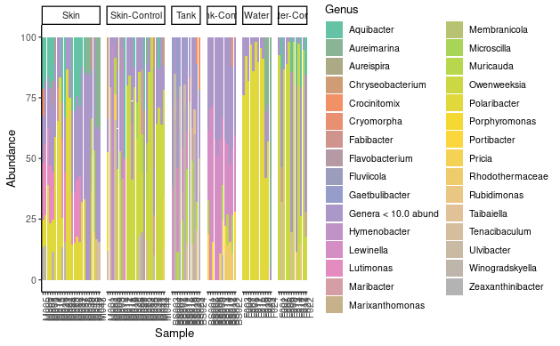

```r
bacteroi_dfps3 <- psmelt(bacteroi_glomps3)
bacteroi_dfps3$Genus[bacteroi_dfps3$Abundance < 10] <- "Genera < 10.0 abund"
bacteroi_dfps3$Genus <- as.factor(bacteroi_dfps3$Genus)

# Define colors for all genera
genus_colors_bacteroi <- colorRampPalette(brewer.pal(8, "Set2"))(length(levels(bacteroi_dfps3$Genus)))

# Set color for specific genus (GenusA)
#genus_colors_proteo[proteo_dfps3$Genus == "GenusA"] <- "red"

plot_bacteroips3 <- ggplot(data = bacteroi_dfps3, aes(x = Sample, y = Abundance, fill = Genus)) +
  geom_bar(aes(), stat = "identity", position = "stack") +
  scale_fill_manual(values = genus_colors_bacteroi) +
  theme_classic() +
  theme(axis.text.x = element_text(angle = 90, hjust = 1)) +
  facet_grid(. ~ treatment, scales = "free_x", space = "free_x")

plot_bacteroips3
ggsave("Bacteroi-genus barplot-filtered.pdf", height = 4, width = 16, device = "pdf")# save a PDF 4 inches by 16 inches
```

[figure not shown]

```r
# Load the vegan package
library(vegan)

# Perform PERMANOVA analysis
result <- adonis(Abundance ~ temperature + day, data = proteo_df, permutations = 999)

# Print the result
print(result)
```

##Prevalence Filtering The previous filtering steps are considered supervised, because they relied on prior information that is external to this experiment (a taxonomic reference database). This next filtering step is completely unsupervised, relying only on the data in this experiment, and a parameter that we will choose after exploring the data. Thus, this filtering step can be applied even in settings where taxonomic annotation is unavailable or unreliable.

First, explore the relationship of prevalence and total read count for each feature. Sometimes this reveals outliers that should probably be removed, and also provides insight into the ranges of either feature that might be useful. This aspect depends quite a lot on the experimental design and goals of the downstream inference, so keep these in mind. It may even be the case that different types of downstream inference require different choices here. There is no reason to expect ahead of time that a single filtering workflow is appropriate for all analysis.

```r
# Define prevalence threshold as 5% of total samples
#prevalenceThreshold = 0.05 * nsamples(ps3)
#prevalenceThreshold
```

```r
# Execute prevalence filter, using `prune_taxa()` function
#keepTaxa <- rownames(prevdf1)[(prevdf1$Prevalence >= prevalenceThreshold)]
#ps4 <- prune_taxa(keepTaxa, ps3)
```

```r
# Remove Kingdom, Phylum, Class, Order, Family columns as they contain same information in each row
hmp_prevdf1 <- prevdf1[, -c(3:7)]

# Scale the data using row Z-scores
df_scale <- apply(hmp_prevdf1, 1, scale)

# Create heatmap using heatmap.2 function
heatmap.2(df_scale, trace = "none", dendrogram = "both", key = TRUE, keysize = 1.2, cexRow = 0.8, cexCol = 0.8, margins = c(10,10))
```